# Statistics without spreadsheet

Tomasz Przechlewski

March, 2019

## Who am I

My name is Tomasz Plata-Przechlewski and I live in Poland. I was born on 16th june 1963 (it was Sunday, the exact day when Valentina Vladimirovna Tereshkova was launched into space – if you know who she is).

BTW in Poland born-in-sunday means work-shy (ie. lazy) person (so you know now first Polish? proverb)

BTW by pure statistics $1/7 \approx 14$% of the population is work-shy:-)

I graduated economy long time ago and teached statistics and information systems (mainly). I am a big fan of open source software and know a few system including Linux and LaTeX. And of course R which I am about to show you in a while.

My hobby is Road Cycling and History. A I am also a amateur photographer. (cf [tprzechlewski@flickr](https://www.flickr.com/photos/tprzechlewski/))

## Agenda

Statistics (nothing spectacular, just classical EDA)

Statistical software (modern, non-standard or hipster #youcall)

Poland (via statistical examples)

## Three components of Statistics

Theory (models) + Tools (programs) + Practice (real data)

Undergraduate courses in social sciences in Poland concentrate on theory, use Spreadsheet as an universal computing tool Office-like editor (MS Word/OO Writes) as an universal publishing tool. Students works with artificial (clean) and small data sets thus are unaware of problems related to applying theory to practice.

It is claimed that the above scenario is optimal. More advanced tools would be too difficult (and time consuming) to be acquinted to by students, thus distracting them from the main subject of the course, ie statistical methods.

Office sofware has limits. Spreadheets are good for number crunching, but are not so good in: data cleaning (Practice), advanced graphics, spatial analysis (T), team work(Practice). Office editors or Powerpoint/ are great tools but are not quality publishing of statistical results.

In my (humble) opinion it is completny wrong not to use some modern tools even in introductory courses as it is (often) the only lectures undergraduta students complete.

I will try to demonstrate that using modern tools for statistical analysis is the way to go. That (some) modern tools are not more difficult that office software (at higher than basic level)

Conclusion: less theory, more pratice and common sense.

## Learnig curve comparison

## Learning statistic to social-science studies in Poland

Typically a statistical course for undergraduate students in social sciences in Poland contains: descriptive statistics for one variable, descriptive methods for an association of two variables elementary time series analysis (moving averages, linear trend/seasonality) Interference/probablity calculus is lectured marginally or omitted as well as graphical methods and information visualization.

Oversimplistic ‘value chain’ of statistical analysis

model/description -> interpretation

raw data -> consistent data -> results -> publishing

## Example: Full Time Equivalence (FTE)

Number of students.

Who is a student?

Student is a person attending to a 3rd level status school in in the 3-stage education system (cf Educational_stage). The answer is still non-obvious as there are many forms of teriary education. For example:

The UNESCO stated that tertiary education focuses on learning endeavors in specialized fields. It includes academic and higher vocational education.

So according to the above definition the school do not belongs to tertiary education if its status is not academic and/or higher vocational. Example: Dance Academy or University for Elderly people (aka University of the 3rd Age). Both are popular in Poland.

In many countries there are some certification scheme. For example in Poland a school must apply (and get) a certificate to be regarded as high school (ie part of tertiary level of education)

Heads vs Majors

Student can be enrolled to more than one course (major). So for counting heads it is necessary to remove duplicates otherwise one would count majors not persons.

Part time studies

FTE stands for Full-Time-Equivalent, an approximation of the number of students who would be enrolled full-time

Full time equivalent (FTE) – FTE is based on student credit hours. It is obtained by dividing student credit hours by some a number of credit hours for full-time-study.

Conclusion: Majors, Persons or FTEs? Which is the best?

[University of Utah/Office of Analysis, Assessment and Accreditation](http://www.usu.edu/aaa/about_our_data.cfm) google:single multiple majors fte

## Example: measurement of tourism activity [concept of an Indicator]

Who is a tourist. According to Glossary:Tourism

Tourism means the activity of visitors taking a trip to a main destination outside their usual environment, for less than a year, for any main purpose, including business, leisure or other personal purpose, other than to be employed by a resident entity in the place visited.

According to the above definition to be regarded as tourist one has to change her/his accomodation place for less than one year (otherwise Eurostat would regard her/him as migrat)

The usual meaning (at least in Poland) is that tourist is travelling for leasure not to work. Poeple travelling to work has other needs/aims than those travelling to rest (they usually do not use hotels for example) so the above definition solves some problems but at the same time creates many others.

Number of tourists: do not distinguish between various form of turists, difficult to collect (who is a turist anyway?)

Various `number of’ tourist-oriented establishments (hotels, catering units, beds, nights spent) etc. They do not measure turists per-se but are highly related and more reliable (as easier to count).

Indicator of turist activity (by various tourist types).

Conclusion: measurement of tourism activity is not trival Other similar: internet user, migrant, unemployed person, illiterate person

## Example: measurement of tourism activity [data collection]

Tourism supply statistics (accommodation statistics): Data on rented accommodation ie. capacity and occupancy of tourist accommodation establishments in the reporting country. How collected? Registers?

Quirks of data collection: Data up to year 2015 inclusive refer to only those units that made the statistical reports. Starting of data for January 2016, the method of imputation data was implemented (ie replacing missing data with some (possibly meaningful :-)) values. (cf [BDL](https://bdl.stat.gov.pl/BDL/dane/podgrup/temat/18/240/2396))

Tourism demand statistics: Data on participation in tourism of the residents of the reporting country. How collected? Surveys?

Most of the time, data on domestic and outbound trips (where “outbound tourism” means residents of a country travelling in another country) is collected via sample surveys (cf [Annual data on trips of EU residents](https://ec.europa.eu/eurostat/cache/metadata/en/tour_dem_esms.htm) and Tourism_statistics_-_top_destinations)

Regulations concerning data collection in turism (hundreds of pages): Glossary:Supply_side_tourism_statistics and [EU regulation No 692/2011](https://eur-lex.europa.eu/legal-content/EN/ALL/?uri=CELEX:32011R0692)

So now we know what we are dealing with…

## Example nights spent (demand side)

Share of nights spent at EU-28 tourist accommodation by tourists travelling outside their own country of residence, 2017 [Share of nights spent at EU-28 tourist accommodation by tourists travelling outside their own country](http://appsso.eurostat.ec.europa.eu/nui/submitViewTableAction.do)

Country of residence -> Foreign country (estimated data)

| year | 2008 | 2009 | 2010 | 2011 | 2012 | 2013 | 2014 | 2015 | 2016 | 2017 |
| --- | --- | --- | --- | --- | --- | --- | --- | --- | --- | --- |
| # | 10173237 | 9609447 | 10064628 | 10620264 | 11876599 | 12471268 | 12992241 | 13757657 | 15579225 | 16705215 |

```
##  [1] 10173237  9609447 10064628 10620264 11876599 12471268 12992241
##  [8] 13757657 15579225 16705215
```

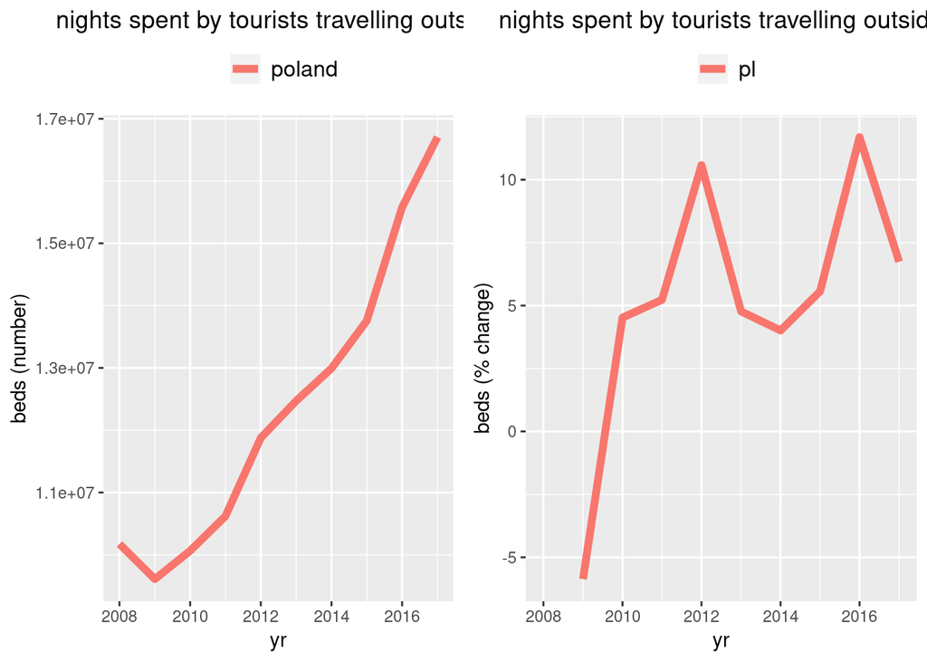

to be continued…

## Dreadful example: Purchasing Power Parity, inflation

and international comarison of GDP

## Modern Approach

[czy-ukraincy-wiaza-swoja-przyszlosc](https://selectivv.com/czy-ukraincy-wiaza-swoja-przyszlosc-z-naszym-krajem-najnowsze-badanie-selectivv/)

[Why universities for the elderly are booming in China](https://www.economist.com/the-economist-explains/2018/08/16/why-universities-for-the-elderly-are-booming-in-china) [yyy](https://polon.nauka.gov.pl/opi/aa/rejestry/szkolnictwo?execution=e4s1)

## Measures of central tendency, dispersion and skewness

(univariate analysis)

The CSV file hotele_caloroczne_PL.csv contains data on number of all-season hotels in every county in Poland. First one has to load the dataset with the read.csv command:

```r
d <- read.csv("hotele_caloroczne_PL.csv", sep = ';',  header=T, na.string="NA")
```

Computing measures of central tendency (with summary and/or fivenum)

```r
summary(d)
```

```
##      teryt              powiat      hotele2012        hotele2017
##  Min.   : 201   bielski    :  2   Min.   :  0.000   Min.   :  0.00
##  1st Qu.:1005   brzeski    :  2   1st Qu.:  3.000   1st Qu.:  4.00
##  Median :1636   grodziski  :  2   Median :  5.000   Median :  7.00
##  Mean   :1721   krośnieński:  2   Mean   :  8.776   Mean   : 10.31
##  3rd Qu.:2475   nowodworski:  2   3rd Qu.: 10.000   3rd Qu.: 11.00
##  Max.   :3263   opolski    :  2   Max.   :158.000   Max.   :183.00
##                 (Other)    :368   NA's   :1
```

```r
fivenum(d$hotele2017)
```

```
## [1]   0   4   7  11 183
```

Computing mean:

```r
mean(d$hotele2017)
```

```
## [1] 10.31053
```

And dispersion:

```r
var(d$hotele2012); var(d$hotele2017)
```

```
## [1] NA
```

```
## [1] 244.8743
```

```r
sd(d$hotele2012); sd(d$hotele2017)
```

```
## [1] NA
```

```
## [1] 15.64846
```

Second attempt (and more compact output):

```r
c(var(d$hotele2012, na.rm=T), var(d$hotele2017, na.rm=T),
 sd(d$hotele2012, na.rm=T), sd(d$hotele2017, na.rm=T))
```

```
## [1] 183.11094 244.87430  13.53185  15.64846
```

BTW:

```r
c( mean(d$hotele2012, na.rm=T), mean(d$hotele2017, na.rm=T))
```

```
## [1]  8.775726 10.310526
```

Or more formally. There were 8.7757256 hotels on the average in every county in Poland in 2012 while in 2017 there were 10.3105263 hotels.

Interquartile Range aka IQR which is the range from the upper (75%) quartile to the lower (25%) quartile. IQR represents central 50% observations of a population. IQR is a robust measure of dispersion, unaffected by the distribution of data:

```r
c( IQR(d$hotele2012, na.rm=T), IQR(d$hotele2017, na.rm=T))
```

```
## [1] 7 7
```

## Measures of concentration/inequality distribution (univariate analysis)

Some variables by definition are positive (or non-negative): income, market share.

[sampling-distribution-of-gini-coefficient](https://www.r-bloggers.com/sampling-distribution-of-gini-coefficient/) income-inequality

## Diversion: R

## Diversion: Rstudio

## Charts (purpose of)

Decoration,

One graph is more effective than another if its quantitative information can be decoded more quickly/easily [Robbins 2005]

## Types of charts

Recommended: (ordered) dot plots, bar charts, histograms and kernel density estimates, multipanel displays (instead of stacked bars multiple line/dot plots) scatterplots (two variables)

Not recommended: Pie charts, bubble charts, stacked bar charts,

Bar/line/pie charts introduced by James Playfair in XVIII century. Dot plots introduced by Cleveland (1980s). Box-plots introduced by Tukey (1970s)

Never use (pseudo) 3D charts for 2D data. Virtually no-one can read them

## Pie charts

[Nights spent by non residents](https://ec.europa.eu/eurostat/statistics-explained/index.php/Tourism_statistics#Nights_spent_by_non-residents_in_the_EU-28:_Spain_on_top)

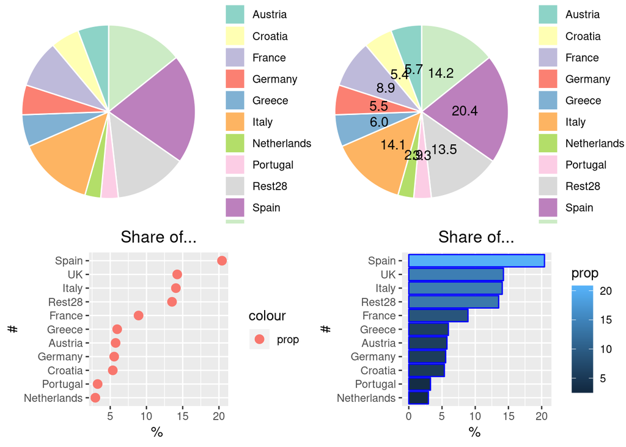

## Dot plots

Jittering: adding random noise to data to avoid overlapping.

## Bar charts

## Histograms and kernel density functions

Histograms show the distribution of a set of data. To draw a histogram the numbers (observations) are grouped into bins (intervals or classes). There is a tradeoff between showing details or showing an overall picture. When bin width changes the scale at Y-axis changes as well (more bins less observations in each bin).

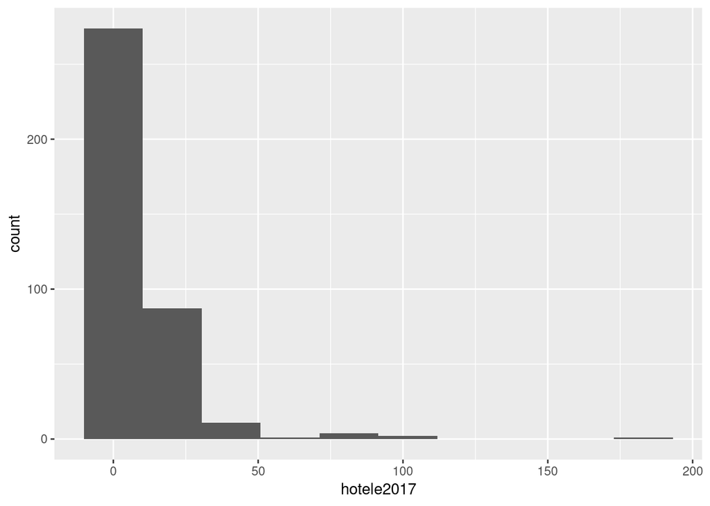

```r
ggplot(d, aes(x = hotele2017)) +
  geom_histogram(bins = nclass.Sturges(d$hotele2017))
```

Histograms with binwidth equal to 20,10, 5 and 1 respectively:

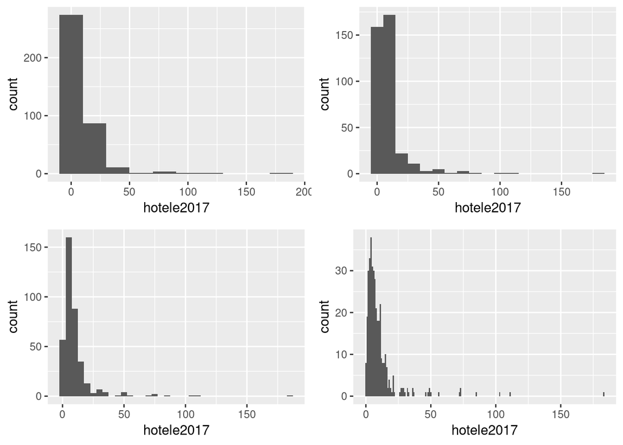

Kernel density functions

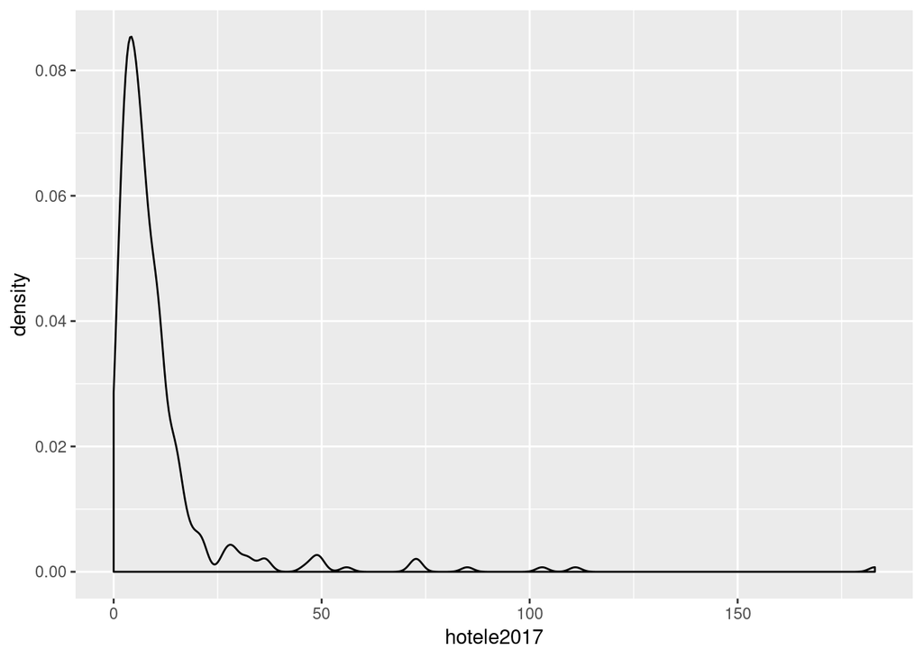

```r
ggplot(data=d) + geom_density(aes(x=hotele2017))
```

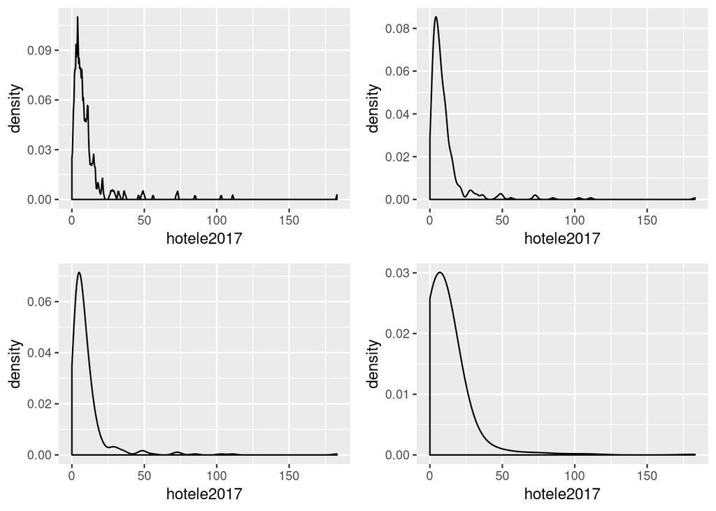

```r
p1 <- ggplot(data=d) + geom_density(aes(x=hotele2017), adjust=0.25)
p2 <- ggplot(data=d) + geom_density(aes(x=hotele2017), adjust=1.0)
p3 <- ggplot(data=d) + geom_density(aes(x=hotele2017), adjust=2.0)
p4 <- ggplot(data=d) + geom_density(aes(x=hotele2017), adjust=8.0)
ggarrange(p1,p2,p3,p4)
```

## Comparing distributions box-plots vs multiple histograms

Box-plots are much better than histograms for comparing distributions of more than one data sets.

Construction of a (typical) box-plot: The middle bar is a median. Top/bottom bars of the rectangle shows the IQR (interquartille range is 1st and 3rd  
quartille), the fanciful bars above/below rectangle called whiskers (google: whiskers mustache :-) are 1,5 times the IQR (or minimu/maximum if those values are less than plus/minus 1,5 IQR. The symbols above/below whiskers (usually open circles) are outliers (non typical/extreme values)

Note the trick: outliers are defined not as (for example) top/botom 1% fraction of values (every distribution would has outliers in such a case) but as values less/more than Me - 1,5IQR (distributions with medium variablity would not have outliers)

Example: age of Nobel-prize winners (cf [The Nobel Prize API Developer Hub](https://nobelprize.readme.io/))

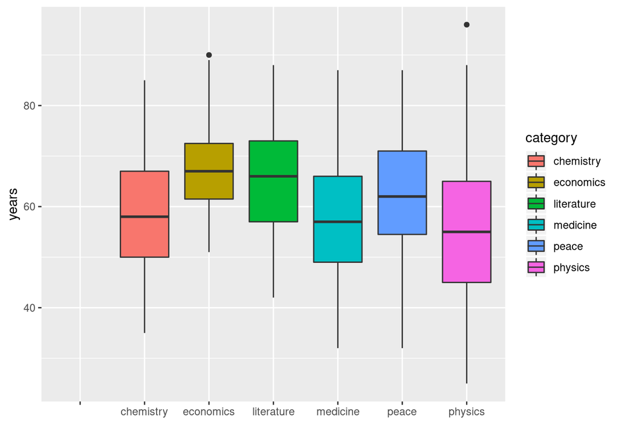

```r
d <- read.csv("nobel_laureates3.csv", sep = ';', dec = ",",  header=T, na.string="NA");

ggplot(d, aes(x=category, y=age, fill=category)) + geom_boxplot() + ylab("years") + xlab("");
```

Multiple histograms are too detailed (binwidth=5). It is impossible for example to establish which category has the youngest (on the average) laureate, or which category has an oldest one (economics and literature are candidates, but due to multimodality of literature laureates distribution it is difficult to assess this for sure…)

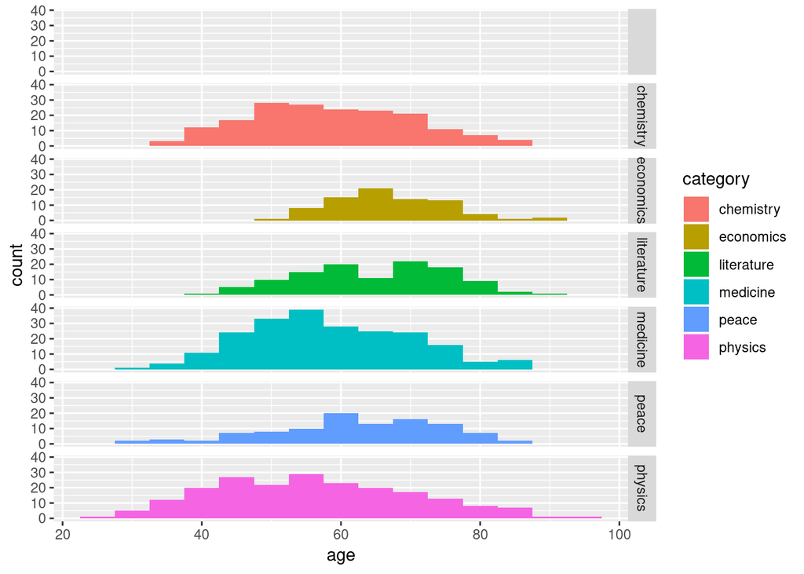

```r
ggplot(d, aes(x=age, fill=category)) + geom_histogram(binwidth=5) +
    facet_grid(category ~ .)
```

## Scatter-plots

A scatter-plot (aka scatter diagrams, xyplot) is a basic form used for two (quantitive) variables.

To see the relationship between variables, a line is can be fitted. Least square (LS) line which assumes linear relationship between variables, is fitted by minimizing the sum of squares of the residuals (residual is the difference between a data-point and a relevant line-point ie a point computed from the formula y = a +bx where x is the value of the x-axis variable.)

Alternatively loess curve can be used which do not assumes linearity.

## Scales

Logarithmic scale makes it possible to plot values with too wide range for a linear scale. Base 10 logarithms `squeeze' the numbers more than base 2 logarithms (log10(100)=2 wile log2(100)=6.64. Moreover is the original scale contains multiplications of 10 use log10 to get`nice’ log-scale while it contains multiplications of 2 use log2.

Logarithms transforms additive scale to `multiplicative’ one. Example (Nobel prize again):

```r
dA <- read.csv("nobel_laureates3.csv", sep = ';', dec = ",",  header=T, na.string="NA");
nrow(dA)
```

```
## [1] 934
```

```r
dS <-  subset(dA, (! bornCountryCode == "" )) ## by country of birth
nrow(dS) ## how many
```

```
## [1] 901
```

Finally plot the resulting data using various Y-axis scales (arithmetic, log2 and log10)

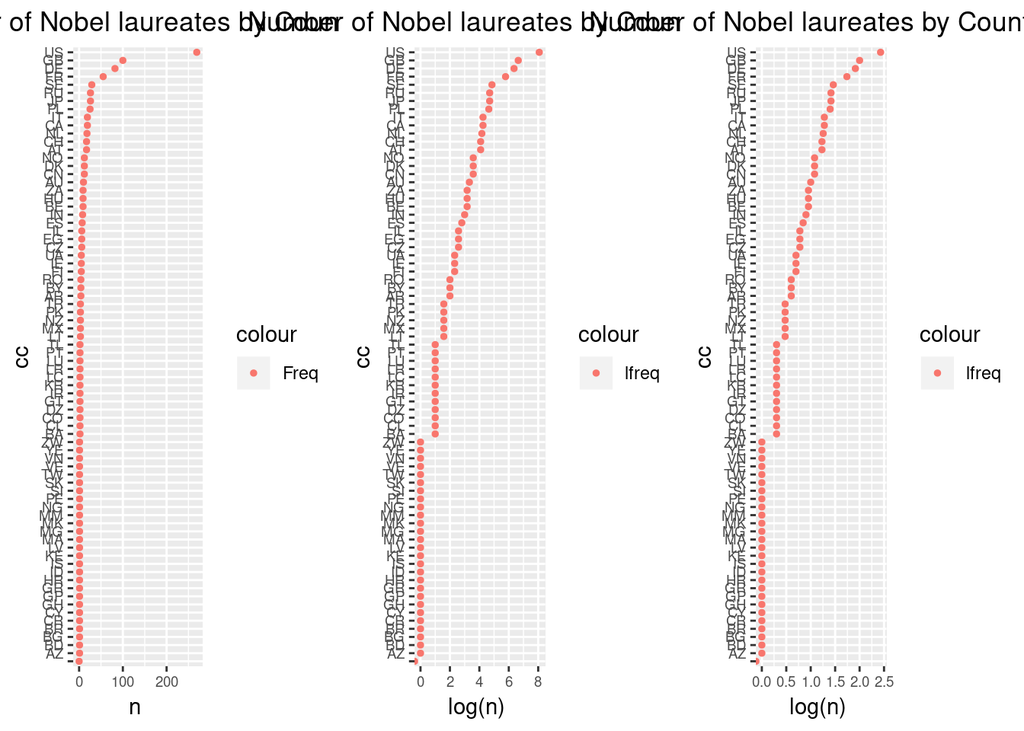

## Graphic perception tasks

Position along common scale Position along common but nonaligned scales Length Angle (slope) Area Volume Color (hue), Color (saturation), Color (density of black)

Angle judgement is not precise. Acute angles are underestimated while obtuse angles (greater than 90) are overestimated.

Area judgement is biased as well. It is impossible to distinguish small differences in area, while quite easy when the same date is plotted along common scale

The most accurate of graphic task is positioning along common scale

## Banking to 45

The ratio between the width and the height of a rectangle is called its aspect ratio.

The aspect ratio describes the area that is occupied by the data in the chart. A change in aspect ratio changes the perception of the graph. The question is which aspect ratio is the best.

We can recognize change most easily if absolute slopes equals to 45 degree angle on the graph. It is much harder to see change if the curves are nearly horizontal/vertical. The idea (Cleveland, 1988) behind banking is therefore to adjust the aspect ratio of the entire plot in such a way that most slopes are at an approximate 45 degree angle.

Setting the aspect ratio so that the average of the values of the orientations is 45 degrees is called “banking the average orientation to 45 degrees”.

Setting the aspect ratio so that the weighted mean of line segments (weighted by segments’ length is approx 45 degrees is called average weighted orientation method (to 45 degrees).

## Diversion: R (making charts)

## The lie factor and data-ink ratio [Tufte]

## Example: education system in Poland

## Elementary spatial analysis (Heat maps/tematic maps)

Geocoding and reversegecoding

## Diversion: tools for geocoding and reversegecoding

## Diversion: tools for building (heat/tematic maps)

QGis

## Example: Poland (population, incomes, distribution of)

## More examples of spatial charts

## Summary: bad graphics examples

## Bivariate analysis

## Example: tourist vs industry vs education (in Poland)

## Example:

## Timeseries analysis

## Bad example: tourists at Malbork castle

[The determinants of the tourist traffic in the castle’s museum of Malbork](http://www.ojs.ukw.edu.pl/index.php/johs/article/view/4119/pdf)

## Elementary spatial analysis

## Example: industry concentration (in Poland)

## Information presentation by Edward Tufte

## Tufte’s famous slide

## Resources

[cheatsheets](https://www.rstudio.com/resources/cheatsheets/) [QGIS tutorials](https://www.qgistutorials.com/en/docs/) [gis.stackexchange.com](https://gis.stackexchange.com/)

## Data banks

## Tourism cd

[nui](http://appsso.eurostat.ec.europa.eu/nui/submitViewTableAction.do)

## Kaggle (Coffee production/consumption)

icos-crop-data exploring-coffee-production-and-consumption ico-coffee-crop-data-data-wrangling

## Varia

[hours-worked](https://data.oecd.org/emp/hours-worked.htm)

## New practice [recap]

Introduce reproducible research approach

Use real (big and dirty) data sets.

Introduce some programming (Programing or using mouse?)

Introduce some new tools (R/Rstudio, QGIS, Github)

## Diversion: Github

## New Tools (hipster part)

R/Rstudio for computing and data visualization

Github for enhancing team work

markdown for reproducible research

## More Data banks

[UK immigration-statistics](https://www.gov.uk/government/statistics/immigration-statistics-year-ending-september-2018-data-tables)

## Example educational resources

https://git.generalassemb.ly/briancwq/classes/blob/master/week-01/lessons/python-descriptive_statistics_numpy-lesson-master/archive/LESSON.md

[ukraine-deputies](https://www.kaggle.com/piterfm/ukraine-deputies#ukraine_deputies.csv)

## Questions

## Thanks